# Score Matching and Langevin Dynamics:

In this section, we will implement Langevin Dynamics on a simple 2D Mixture of Gaussians Model.

It is prohibited to use the library `torch.distributions` throughout this homework, as well as any other libraries that do similar calculations such as `scipy.stats`.

Note that GPUs will not help in any part except the final section with the generation of images (everything else runs in less than a second), so it is recommended to run this part of the homework on a local CPU.

```python
import torch
import torch.nn as nn
import torch.nn.functional as F
import torch.optim as optim
import torch.nn.init as init
import numpy as np
import random
import matplotlib.pyplot as plt
```

```python
import math
```

## Part 1: Computing the density and score of a Gaussian Mixture Model

A Gaussian Mixture Model is a distribution that is the combination of several Gaussian distributions, such as the following:

$$ X | Y \sim \mathcal{N}(\mu_1, \sigma_1 I)Y + \mathcal{N}(\mu_2, \sigma_2 I)(1 - Y) $$

where $Y \sim \text{Ber}(p)$. In our case, $X \in \mathbb{R}^2$.

Implement the following functions to compute the density and score of a GMM. You can add any other functions required. For score computation, do not use torch's autograd (it will greatly hinder the performance).

```python
mu_1 = torch.tensor([1., 1.])
mu_2 = torch.tensor([-1., -1.])

sigma_1 = torch.sqrt(torch.tensor(0.1))
sigma_2 = torch.sqrt(torch.tensor(0.1))

p_first = torch.tensor(0.15)  # The probability that I will sample from the first distribution.
```

```python
def density_gmm(X, mu_1, mu_2, sigma_1, sigma_2, p):
    """
    :param X: input data: tensor of shape (N, 2)
    :param mu_1: mean of the first Gaussian
    :param mu_2: mean of the second Gaussian
    :param sigma_1: standard deviation of the first Gaussian
    :param sigma_2: standard deviation of the second Gaussian
    :param p: probability of the first Gaussian
    :return: density of the Gaussian Mixture Model at point X: tensor of shape (N,)
    """
    N, D = X.shape

    diff1 = X - mu_1  # shape (N,2)
    diff2 = X - mu_2

    sq_maha1 = (diff1**2).sum(dim=1)  # shape (N,)
    sq_maha2 = (diff2**2).sum(dim=1)

    # normalization constants for each isotropic Gaussian in D dims:
    # (2π)^(D/2) * σ^D
    const1 = (2 * math.pi)**(D/2) * (sigma_1**D)
    const2 = (2 * math.pi)**(D/2) * (sigma_2**D)

    # component densities
    N1 = torch.exp(-0.5 * sq_maha1 / (sigma_1**2)) / const1  # shape (N,)
    N2 = torch.exp(-0.5 * sq_maha2 / (sigma_2**2)) / const2

    return p * N1 + (1 - p) * N2
```

```python
def score_gmm(X, mu_1, mu_2, sigma_1, sigma_2, p):
    """
    :param X: input data: tensor of shape (N, 2)
    :param mu_1: mean of the first Gaussian: tensor of shape (2,)
    :param mu_2: mean of the second Gaussian: tensor of shape (2,)
    :param sigma_1: standard deviation of the first Gaussian: tensor of shape (1,)
    :param sigma_2: standard deviation of the second Gaussian: tensor of shape (1,)
    :return: score of the Gaussian Mixture Model at point X: tensor of shape (N, 2, 2)
    """
    # first compute the component densities
    N1 = density_gmm(X, mu_1, mu_2, sigma_1, sigma_2, torch.tensor(1.0))  # gives N(x|μ₁)
    N2 = density_gmm(X, mu_1, mu_2, sigma_1, sigma_2, torch.tensor(0.0))  # gives N(x|μ₂)

    # responsibilities (unnormalized)
    w1_unnorm = p * N1  # shape (N,)
    w2_unnorm = (1 - p) * N2
    Z = w1_unnorm + w2_unnorm    # shape (N,)

    # normalized weights
    w1 = w1_unnorm / Z  # shape (N,)
    w2 = w2_unnorm / Z

    # component‐wise score vectors: ∇ₓ log N_k(x) = −(x − μ_k) / σ_k²
    diff1 = X - mu_1      # (N,2)
    diff2 = X - mu_2
    score1 = - diff1 / (sigma_1**2)  # (N,2)
    score2 = - diff2 / (sigma_2**2)

    # mixture score: weighted sum of component scores
    # (N,1) * (N,2) → (N,2)

    return w1.unsqueeze(1) * score1 + w2.unsqueeze(1) * score2
```

### Visualization

Using a heatmap (with plt.imshow) and an arrow plot (plt.quiver), generate a plot of the density function and score.

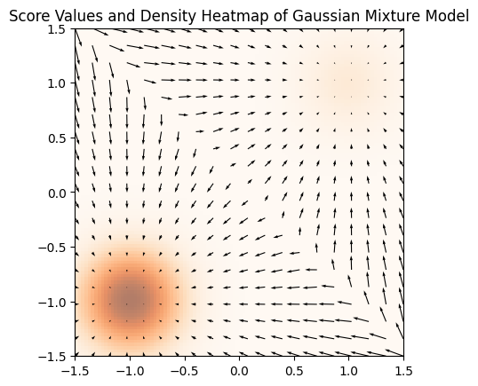

```python
# Steps:
# 1. Create a grid from -1.5 to 1.5 in both dimensions, with 100 points in each dimension (using torch.linspace and torch.meshgrid)
# 2. Compute the density of the Gaussian Mixture Model at each point on the grid and store it in a tensor of shape (100, 100)
# 3. For the quiver plot, create a grid from -1.5 to 1.5 in both dimensions, with 20 points in each dimension
# 4. Compute the score of the Gaussian Mixture Model at each point on the grid and store it in a tensor of shape (20, 20, 2)
# 5. Create a quiver plot with the grid points as the X and Y coordinates and the score as the U and V components
# 6. Create a heatmap of the density, with the grid points as the X and Y coordinates and the density as the color, becoming darker as the density is larger

DENSITY_GRID_SIZE = 100
SCORE_GRID_SIZE = 20

density_grid = torch.zeros(DENSITY_GRID_SIZE, DENSITY_GRID_SIZE)  # Replace this with the relevant matrix, using torch.linspace and torch.meshgrid
score_grid = torch.zeros(SCORE_GRID_SIZE, SCORE_GRID_SIZE, 2)  # Replace this with the relevant matrix, using torch.linspace and torch.meshgrid
density_values = torch.zeros(DENSITY_GRID_SIZE, DENSITY_GRID_SIZE)  # Fill this with the density values
score_values = torch.zeros(SCORE_GRID_SIZE, SCORE_GRID_SIZE, 2)  # Fill this with the score values

#### ADD YOUR CODE HERE ####

# 1. Density grid
x = torch.linspace(-1.5, 1.5, DENSITY_GRID_SIZE)
y = torch.linspace(-1.5, 1.5, DENSITY_GRID_SIZE)
grid_x, grid_y = torch.meshgrid(x, y, indexing='xy')  # shape (100,100)
points = torch.stack([grid_x.flatten(), grid_y.flatten()], dim=1)  # shape (10000,2)
density = density_gmm(points, mu_1, mu_2, sigma_1, sigma_2, p_first)
density_values = density.reshape(DENSITY_GRID_SIZE, DENSITY_GRID_SIZE)

# 2. Score grid
x2 = torch.linspace(-1.5, 1.5, SCORE_GRID_SIZE)
y2 = torch.linspace(-1.5, 1.5, SCORE_GRID_SIZE)
score_x, score_y = torch.meshgrid(x2, y2, indexing='xy')  # shape (20,20)
score_points = torch.stack([score_x.flatten(), score_y.flatten()], dim=1)  # shape (400,2)
scores = score_gmm(score_points, mu_1, mu_2, sigma_1, sigma_2, p_first)
score_values = scores.reshape(SCORE_GRID_SIZE, SCORE_GRID_SIZE, 2)
score_grid = torch.stack([score_x, score_y], dim=2)  # shape (20,20,2)

#### DONE WITH SOLUTION ####

plt.imshow(density_values, extent=(-1.5, 1.5, -1.5, 1.5), origin='lower', cmap='Oranges', alpha=0.6)
plt.quiver(score_grid[:, :, 0], score_grid[:, :, 1], score_values[:, :, 0], score_values[:, :, 1], color='black')
plt.title('Score Values and Density Heatmap of Gaussian Mixture Model')
plt.show()
```

## Part 2: Training a score network

Implement a model that is able to compute the score of a given point sampled from the GMM.

```python
class ScoreMatcher(nn.Module):
    """
    A simple MLP that approximates the score function (gradient of log density)
    of a Gaussian Mixture Model for input points in R^2.
    """
    def __init__(self, input_dim=2, hidden_dims=[128, 128], output_dim=2):
        """
        Initializes the ScoreMatcher model.

        :param input_dim: dimensionality of the input (default 2 for R^2)
        :param hidden_dims: list containing the number of units in hidden layers
        :param output_dim: dimensionality of the output (default 2, the score per coordinate)
        """
        super(ScoreMatcher, self).__init__()
        layers = []
        in_dim = input_dim
        # Create the hidden layers.
        for hidden_dim in hidden_dims:
            layers.append(nn.Linear(in_dim, hidden_dim))
            layers.append(nn.ReLU())
            in_dim = hidden_dim
        # Final linear layer to produce output.
        layers.append(nn.Linear(in_dim, output_dim))
        self.net = nn.Sequential(*layers)

    def forward(self, x):
        """
        Forward pass: compute the score for given input points.

        :param x: input tensor of shape (N, 2)
        :return: output tensor of shape (N, 2) representing the score function
        """
        return self.net(x)
```

```python
def train(mu_1, mu_2, sigma_1, sigma_2, p, train_size, num_epochs, lr):
    """
    Trains a ScoreMatcher model on data sampled from a Gaussian Mixture Model.

    :param mu_1: Mean of the first Gaussian (tensor of shape (2,))
    :param mu_2: Mean of the second Gaussian (tensor of shape (2,))
    :param sigma_1: Standard deviation of the first Gaussian (scalar, tensor or float)
    :param sigma_2: Standard deviation of the second Gaussian (scalar, tensor or float)
    :param p: Mixing probability for the first Gaussian (scalar)
    :param train_size: Number of training samples to generate
    :param num_epochs: Number of training epochs
    :param lr: Learning rate for the optimizer
    :return: A trained ScoreMatcher model
    """
    # --- 1. Create training samples from the GMM ---
    # Sample a Bernoulli indicator for each sample:
    mask = torch.bernoulli(torch.full((train_size,), p))
    # Preallocate the training data tensor:
    X_train = torch.empty(train_size, 2)
    # For points assigned to component 1:
    comp1_indices = (mask == 1).nonzero(as_tuple=True)[0]
    if comp1_indices.numel() > 0:
        X_train[comp1_indices] = mu_1 + sigma_1 * torch.randn(comp1_indices.numel(), 2)
    # For points assigned to component 2:
    comp2_indices = (mask == 0).nonzero(as_tuple=True)[0]
    if comp2_indices.numel() > 0:
        X_train[comp2_indices] = mu_2 + sigma_2 * torch.randn(comp2_indices.numel(), 2)

    # --- 2. Compute ground-truth score for training samples ---
    # We use our closed-form score function for the GMM.
    score_true = score_gmm(X_train, mu_1, mu_2, sigma_1, sigma_2, p)

    # --- 3. Create and train the model ---
    model = ScoreMatcher()
    optimizer = torch.optim.Adam(model.parameters(), lr=lr)
    loss_fn = torch.nn.MSELoss()

    model.train()
    for epoch in range(num_epochs):
        optimizer.zero_grad()
        # Predict score using the model
        score_pred = model(X_train)
        loss = loss_fn(score_pred, score_true)
        loss.backward()
        optimizer.step()

        print(f"Epoch {epoch+1}/{num_epochs}, Loss: {loss.item():.6f}")

    return model
```

Print the loss value at each epoch. Make sure the loss is lower than 0.01

```python
model = train(mu_1, mu_2, sigma_1, sigma_2, p_first, 1000, 1000, 0.01)
```

[output not shown]

Create a similar visualization to the visualization you created with the true score, replacing the true score with the model.

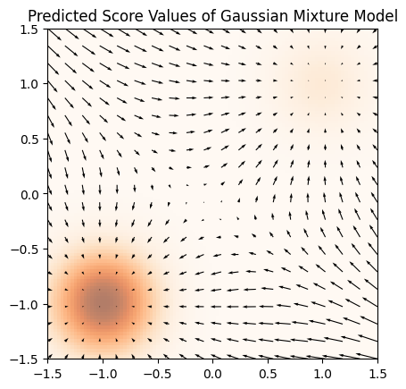

```python
density_grid = None
score_grid = None
density_values = None
score_values = None

#### ADD YOUR CODE HERE ####

# 1–2. Density grid (100×100)
DENSITY_GRID_SIZE = 100
x = torch.linspace(-1.5, 1.5, DENSITY_GRID_SIZE)
y = torch.linspace(-1.5, 1.5, DENSITY_GRID_SIZE)
grid_x, grid_y = torch.meshgrid(x, y, indexing='xy')            # (100,100)
pts = torch.stack([grid_x.flatten(), grid_y.flatten()], dim=1)  # (10000,2)

density_vals = density_gmm(pts, mu_1, mu_2, sigma_1, sigma_2, p_first)
density_values = density_vals.reshape(DENSITY_GRID_SIZE, DENSITY_GRID_SIZE)

# 3–4. Score grid (20×20)
SCORE_GRID_SIZE = 20
x2 = torch.linspace(-1.5, 1.5, SCORE_GRID_SIZE)
y2 = torch.linspace(-1.5, 1.5, SCORE_GRID_SIZE)
score_x, score_y = torch.meshgrid(x2, y2, indexing='xy')         # (20,20)
pts2 = torch.stack([score_x.flatten(), score_y.flatten()], dim=1)  # (400,2)

with torch.no_grad():
    scores_pred = model(pts2)  # (400,2)

score_values = scores_pred.reshape(SCORE_GRID_SIZE, SCORE_GRID_SIZE, 2)
score_grid   = torch.stack([score_x, score_y], dim=2)            # (20,20,2)



plt.imshow(density_values, extent=(-1.5, 1.5, -1.5, 1.5), origin='lower', cmap='Oranges', alpha=0.6)
plt.quiver(score_grid[:, :, 0], score_grid[:, :, 1], score_values[:, :, 0], score_values[:, :, 1], color='black')
plt.title('Predicted Score Values of Gaussian Mixture Model')
plt.show()
```

Compare the visualizations and explain what could be causing the differences.

In the first plot (true scores), the vectors cleanly point toward the two Gaussian modes at (–1, –1) and (1, 1), with magnitudes increasing away from the centers—especially strong near (–1, –1), the dominant mode. The flow is sharp, symmetric, and well-aligned with the density heatmap.

These differences come from the imbalance in training data (most samples come from the dominant mode), leading the model to underfit underrepresented areas. Also, in regions with few or no training samples, the network doesn’t learn a clear pattern and ends up predicting small, vague vectors.

## Part 3: Sampling

In this section we will sample from our distribution using several methods:

1. Directly sampling using torch functions
2. Using Langevin Dynamics using the model that we trained.
3. Using Annealed Langevin Dynamics using the true score function.

Sample 1000 points from the GMM and display them using a scatterplot.

```python
N = 1000
```

[figure not shown]

```python
### YOUR CODE HERE ###

mask = torch.rand(N) < p_first      # Boolean mask for “component 1”
samples = torch.empty(N, 2)

# fill component 1
n1 = mask.sum().item()
samples[mask] = mu_1 + sigma_1 * torch.randn(n1, 2)

# fill component 2
n2 = N - n1
samples[~mask] = mu_2 + sigma_2 * torch.randn(n2, 2)

# 2) convert to NumPy and scatter
pts = samples.cpu().numpy()
plt.figure(figsize=(6,6))
plt.scatter(pts[:,0], pts[:,1], s=10, alpha=0.6)
plt.title('1000 Samples from the GMM')
plt.xlabel('$x_1$')
plt.ylabel('$x_2$')
plt.axis('equal')
plt.grid(True)
plt.show()
```

Sample 1000 points using the score model (Langevin Dynamics).

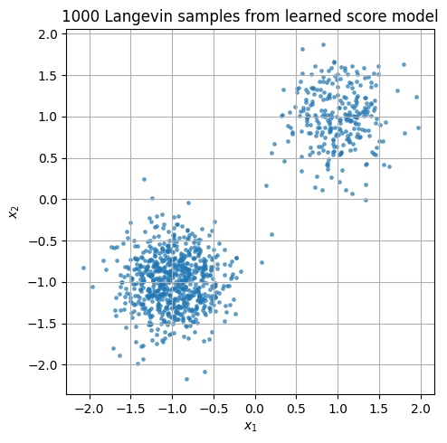

```python
LANGEVIN_STEP_SIZE = 0.01
LANGEVIN_NUM_STEPS = 10000

### YOUR CODE HERE ###

device = torch.device("cuda" if torch.cuda.is_available() else "cpu")
model = model.to(device).eval()

@torch.no_grad()
def langevin_sample(score_model,
                    n_samples: int = 1000,
                    n_steps: int = LANGEVIN_NUM_STEPS,
                    step_size: float = LANGEVIN_STEP_SIZE,
                    init_sigma: float = 1.0,
                    device: torch.device = torch.device("cpu")):
    """
    Langevin Dynamics sampler on GPU (if available).
    """
    x = init_sigma * torch.randn(n_samples, 2, device=device)
    sqrt_2eps = math.sqrt(2. * step_size)

    for _ in range(n_steps):
        x += step_size * score_model(x) + sqrt_2eps * torch.randn_like(x)

    return x.cpu()  # Return to CPU for visualization

# Sample
samples = langevin_sample(model, device=device)

# Visualize
import matplotlib.pyplot as plt
plt.figure(figsize=(5, 5))
plt.scatter(samples[:, 0], samples[:, 1], s=6, alpha=0.6)
plt.title("1000 Langevin samples from learned score model")
plt.xlabel("$x_1$")
plt.ylabel("$x_2$")
plt.axis("equal")
plt.grid(True)
plt.tight_layout()
plt.show()
```

Sample 1000 points using Annealed Langevin Dynamics and the true score function. Show the sample after applying each noise scale. Remember that as the noise is smaller, we want to decrease the step size of Langevin Dynamics, so remember to update the step size according to the following formula:

$$\eta_t = \eta_\text{original} \cdot \frac{\sigma_t^2}{\sigma_T^2}$$

Because we are using normal distributions, the noised distributions $p_\sigma$ will just have more variance.

```
The noise being added to the data at each step is: tensor([2.0000, 1.1101, 0.6162, 0.3420, 0.1898, 0.1054, 0.0585, 0.0325, 0.0180,
        0.0100]) (geometric sequence)
```

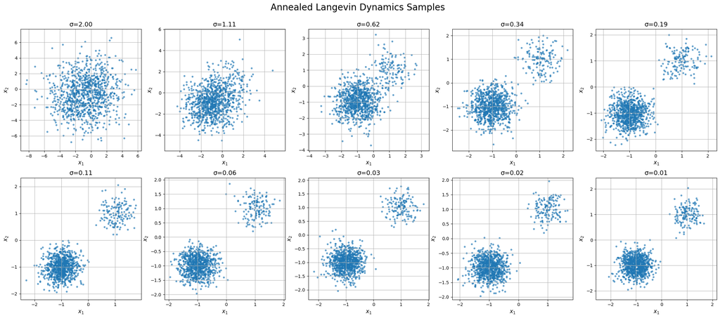

```python
import torch
import matplotlib.pyplot as plt

NOISE_SCALES = torch.logspace(
    torch.log10(torch.tensor(2.0)),
    torch.log10(torch.tensor(0.01)),
    10
)
LANGEVIN_STEP_SIZE = 1e-5
NUM_STEPS_EACH = 500

print(f'The noise being added to the data at each step is: {NOISE_SCALES} (geometric sequence)')


# ---- Score Function ----
def score_gmm_noisy(X, mu1, mu2, sigma1, sigma2, p, sigma_t):
    var1 = sigma1**2 + sigma_t**2
    var2 = sigma2**2 + sigma_t**2

    diff1 = X - mu1
    diff2 = X - mu2

    norm1 = diff1.pow(2).sum(dim=1)
    norm2 = diff2.pow(2).sum(dim=1)

    coef = 1.0 / (2 * torch.pi)
    g1 = coef / var1 * torch.exp(-0.5 * norm1 / var1)
    g2 = coef / var2 * torch.exp(-0.5 * norm2 / var2)

    score1 = -diff1 / var1
    score2 = -diff2 / var2

    mix_density = p * g1 + (1 - p) * g2
    weighted_score = p * g1.unsqueeze(1) * score1 + (1 - p) * g2.unsqueeze(1) * score2

    return weighted_score / mix_density.unsqueeze(1)

# ---- Annealed Langevin Dynamics ----
x = NOISE_SCALES[0] * torch.randn(N, 2)
sigma_T2 = NOISE_SCALES[-1]**2

n_scales = len(NOISE_SCALES)
n_rows = 2
n_cols = math.ceil(n_scales / n_rows)

fig, axes = plt.subplots(n_rows, n_cols, figsize=(n_cols * 4.5, n_rows * 5))
fig.suptitle("Annealed Langevin Dynamics Samples", fontsize=20)
axes = axes.flatten()  # flatten in case it's 2D array of axes

for i, sigma_t in enumerate(NOISE_SCALES):
    eta_t = LANGEVIN_STEP_SIZE * (sigma_t**2) / sigma_T2

    for _ in range(NUM_STEPS_EACH):
        score = score_gmm_noisy(x, mu_1, mu_2, sigma_1, sigma_2, p_first, sigma_t)
        noise = torch.randn_like(x)
        x += eta_t * score + torch.sqrt(2 * eta_t) * noise

    ax = axes[i]
    ax.scatter(x[:, 0].cpu(), x[:, 1].cpu(), s=10, alpha=0.6)
    ax.set_title(f"σ={sigma_t:.2f}", fontsize=14)
    ax.axis('equal')
    ax.set_xlabel("$x_1$", fontsize=12)
    ax.set_ylabel("$x_2$", fontsize=12)
    ax.grid(True)

# Hide any unused subplots
for j in range(i+1, len(axes)):
    axes[j].axis('off')

plt.tight_layout()
plt.subplots_adjust(top=0.9)
plt.show()
```

## Putting it all together!

In this section you will be using everything you learned to generate images from MNIST, provided to you in your virtual machines (and available in Pytorch). Ideas are based on the paper Generative Modeling by Estimating Gradients of the Data Distribution (2019). You can use the paper's official implementation as a guideline to the solution. It is recommended to go over the first tutorial before solving.

```python
device = torch.device('cuda' if torch.cuda.is_available() else 'cpu')
```

### 1 - Denoising Score Matching

When the score function cannot be calculated directly (as above), we cannot simply use the MSE between the model output and the true score. Hence, we updated loss function, suiting it to our annealed noise schedule:

$$\ell_\text{denoise}(\theta; \sigma) := \frac{1}{2}\mathbb{E}_{x\sim p_\text{data}} \mathbb{E}_{\tilde{x}\sim q_\sigma(\cdot | x)} \left[ \Vert s_\theta(\tilde{x}, \sigma) - \log q_\sigma(\tilde{x}|x)\Vert^2 \right]$$ $$ L_\text{denoise}(\theta) = \frac{1}{L}\sum_{i=1}^L \lambda(\sigma_i)\ell_\text{denoise}(\theta; \sigma_i) \equiv \mathbb{E}_{i \sim \text{Uni}(1, L)} \left[ \sigma_i^2\ell_\text{denoise}(\theta; \sigma_i) \right] $$

Where the model is denoted as $s_\theta$ and $\sigma_i$ are the noise values.

```python
def denoising_score_loss(model, x, noise_scales):
    """
    model: The score matching model.
    x: The input data [BATCH_SIZE, WIDTH, HEIGHT]
    noise_scales: The noise scales to use for denoising [NUM_NOISE_SCALES] (sigma_1, sigma_2, ..., sigma_L)
    """
    device = x.device  # infer from data
    noise_scale_idx = torch.randint(0, len(noise_scales), (x.shape[0],), device=device)  # Random noise scale for each sample in the batch
    noise_scale_batch = noise_scales[noise_scale_idx].view(-1, 1, 1, 1)  # all entries in an image x should be perturbed by the same noise scale

    ### YOUR CODE HERE ###

    device = x.device
    batch_size = x.shape[0]

    # Add noise to input
    noise = torch.randn_like(x)
    x_tilde = x + noise_scale_batch * noise

    # Predict score
    pred = model(x_tilde, noise_scale_idx)

    # Target is the negative score of the noise distribution
    target = -noise / noise_scale_batch

    # Weighted MSE loss
    loss = (noise_scale_batch ** 2 * (pred - target).pow(2)).mean()

    return loss
```

### 2 - UNet

A great candidate for a model that receives an image and returns a value that is of the same dimensions as the image is a UNet. Below is a UNet architecture already implemented for you. In this section you don't need to implement / change anything, if you do please specify your changes below.

```python
class CondInstanceNorm(nn.Module):
    def __init__(self, in_channels, n_noise_scale=10, eps=1e-5):
        super().__init__()
        self.gamma = nn.Parameter(torch.ones(n_noise_scale, in_channels))
        self.beta = nn.Parameter(torch.zeros(n_noise_scale, in_channels))
        self.alpha = nn.Parameter(torch.zeros(n_noise_scale, in_channels))
        self.eps = eps

    def forward(self, x, noise_scale_idx):
        bsz = x.shape[0]
        gamma = self.gamma[noise_scale_idx].view(bsz, -1, 1, 1)  # (bsz, in_channels, 1, 1)
        beta = self.beta[noise_scale_idx].view(bsz, -1, 1, 1)
        alpha = self.alpha[noise_scale_idx].view(bsz, -1, 1, 1)


        mu = x.mean(dim=(2, 3), keepdim=True)  # (batch_size, in_channels, 1, 1)
        var = x.var(dim=(2, 3), keepdim=True)  # (batch_size, in_channels, 1, 1)
        sigma = torch.sqrt(var + self.eps)  # (batch_size, in_channels, 1, 1)


        x = (x - mu) / sigma  # (batch_size, in_channels, height, width)
        x = gamma * x + beta  # (batch_size, in_channels, height, width)

        m = mu.mean(dim=1, keepdim=True)  # (batch_size, 1, 1, 1)
        if mu.shape[1] == 1:
            s = torch.ones_like(mu)
        else:
            v = mu.var(dim=1, keepdim=True)  # (batch_size, 1, 1, 1)
            s = torch.sqrt(v + self.eps)  # (batch_size, 1, 1, 1)

        x = x + alpha * (mu - m) / s  # (batch_size, in_channels, height, width)
        return x


class ResidualConvUnit(nn.Module):
    def __init__(self, channels, norm=True, kernel_size=3, n_noise_scale=10):
        super().__init__()
        self.conv1 = nn.Conv2d(channels, channels, kernel_size=kernel_size, padding='same')
        self.conv2 = nn.Conv2d(channels, channels, kernel_size=kernel_size, padding='same')
        self.norm1 = CondInstanceNorm(channels, n_noise_scale) if norm else None
        self.norm2 = CondInstanceNorm(channels, n_noise_scale) if norm else None
        self.act = nn.ELU()

    def forward(self, x, noise_scale_idx):
        # x: (batch_size, in_channels, height, width)
        h = self.norm1(x, noise_scale_idx) if self.norm1 is not None else x
        h = self.act(h)
        h = self.conv1(h)

        h = self.norm2(h, noise_scale_idx) if self.norm2 is not None else h
        h = self.act(h)
        h = self.conv2(h)

        return x + h



class StridedConvUnit(nn.Module):
    def __init__(self, in_channels, out_channels, kernel_size=3, n_noise_scale=10):
        super().__init__()
        self.conv1 = nn.Conv2d(in_channels, out_channels, kernel_size=kernel_size, padding=kernel_size//2, stride=2)
        self.conv2 = nn.Conv2d(out_channels, out_channels, kernel_size=kernel_size, padding='same')
        self.norm1 = CondInstanceNorm(in_channels, n_noise_scale)
        self.norm2 = CondInstanceNorm(out_channels, n_noise_scale)
        self.act = nn.ELU()

    def forward(self, x, noise_scale_idx):
        # x: (batch_size, in_channels, height, width)

        h = self.norm1(x, noise_scale_idx)
        h = self.act(h)
        h = self.conv1(h)

        h = self.norm2(h, noise_scale_idx)
        h = self.act(h)
        h = self.conv2(h)

        return h


class DilatedConvUnit(nn.Module):
    def __init__(self, in_channels, out_channels, kernel_size=3, dilation=2, n_noise_scale=10):
        super().__init__()
        self.conv1 = nn.Conv2d(in_channels, out_channels, kernel_size=kernel_size, dilation=dilation, padding=dilation)
        self.conv2 = nn.Conv2d(out_channels, out_channels, kernel_size=kernel_size, padding='same')
        self.norm1 = CondInstanceNorm(in_channels, n_noise_scale)
        self.norm2 = CondInstanceNorm(out_channels, n_noise_scale)
        self.act = nn.ELU()

    def forward(self, x, noise_scale_idx):
        # x: (batch_size, in_channels, height, width)

        h = self.norm1(x, noise_scale_idx)
        h = self.act(h)
        h = self.conv1(h)

        h = self.norm2(h, noise_scale_idx)
        h = self.act(h)
        h = self.conv2(h)

        return h



class ResidualBlock(nn.Module):
    def __init__(self, in_channels, out_channels, n_layers=2, downsample='stride', dilation=2, n_noise_scale=10):
        assert downsample in ['stride', 'dilation']
        super().__init__()
        self.downsample = downsample
        self.main = nn.ModuleList([])
        for _ in range(n_layers):
            self.main.append(ResidualConvUnit(in_channels, n_noise_scale=n_noise_scale))

        if downsample == 'stride':
            self.main.append(StridedConvUnit(in_channels, out_channels, n_noise_scale=n_noise_scale))
        elif downsample == 'dilation':
            self.main.append(DilatedConvUnit(in_channels, out_channels, dilation=dilation, n_noise_scale=n_noise_scale))

    def forward(self, x, noise_scale_idx):
        # x: (batch_size, in_channels, height, width)

        for layer in self.main:
            x = layer(x, noise_scale_idx)

        return x


class AdaptiveConvBlock(nn.Module):
    def __init__(self, in_channels, out_channels, n_noise_scale=10):
        super().__init__()
        self.conv1 = nn.Conv2d(in_channels, out_channels, kernel_size=1)
        self.conv2 = ResidualConvUnit(out_channels, n_noise_scale=n_noise_scale)
        self.conv3 = ResidualConvUnit(out_channels, n_noise_scale=n_noise_scale)

    def forward(self, x, noise_scale_idx):
        # x: (batch_size, in_channels, height, width)

        h = self.conv1(x)
        h = self.conv2(h, noise_scale_idx)
        h = self.conv3(h, noise_scale_idx)

        return h


class MultiResolutionFusion(nn.Module):
    def __init__(self, channels, n_noise_scale=10):
        super().__init__()
        self.conv1 = nn.Conv2d(channels, channels, kernel_size=3, padding='same')
        self.conv2 = nn.Conv2d(channels, channels, kernel_size=3, padding='same')
        self.norm1 = CondInstanceNorm(channels, n_noise_scale)
        self.norm2 = CondInstanceNorm(channels, n_noise_scale)

    def forward(self, x, y=None, noise_scale_idx=0):
        if y is None:
            return x
        else:
            h1 = self.norm1(x, noise_scale_idx)
            h1 = self.conv1(h1)

            h2 = self.norm2(y, noise_scale_idx)
            h2 = self.conv2(h2)

            return h1 + h2


class ResidualPoolingBlock(nn.Module):
    def __init__(self, channels, n_noise_scale=10):
        super().__init__()
        self.norm1 = CondInstanceNorm(channels, n_noise_scale)
        self.pool1 = nn.AvgPool2d(kernel_size=5, stride=1, padding=2)
        self.norm2 = CondInstanceNorm(channels, n_noise_scale)
        self.conv1 = nn.Conv2d(channels, channels, kernel_size=3, padding='same')

    def forward(self, x, noise_scale_idx):
        h = self.norm1(x, noise_scale_idx)
        h = self.pool1(h)
        h = self.norm2(h, noise_scale_idx)
        h = self.conv1(h)

        return h


class ChainedResidualPool(nn.Module):
    def __init__(self, channels, n_noise_scale=10):
        super().__init__()
        self.act = nn.ELU()
        self.pool1 = ResidualPoolingBlock(channels, n_noise_scale=n_noise_scale)
        self.pool2 = ResidualPoolingBlock(channels, n_noise_scale=n_noise_scale)


    def forward(self, x, noise_scale_idx):
        x = self.act(x)
        h = self.pool1(x, noise_scale_idx)
        x = x + h
        h = self.pool2(h, noise_scale_idx)
        x = x + h

        return x

class RefineNetBlock(nn.Module):
    def __init__(self, x1_in, x2_in, channels, n_noise_scale=10):
        super().__init__()
        self.adap_x1 = AdaptiveConvBlock(x1_in, channels, n_noise_scale=n_noise_scale)
        self.adap_x2 = AdaptiveConvBlock(x2_in, channels, n_noise_scale=n_noise_scale)

        self.fusion = MultiResolutionFusion(channels, n_noise_scale=n_noise_scale)
        self.pool = ChainedResidualPool(channels, n_noise_scale=n_noise_scale)

        self.out = ResidualConvUnit(channels, n_noise_scale=n_noise_scale)

    def forward(self, x1, x2=None, noise_scale_idx=0):
        h1 = self.adap_x1(x1, noise_scale_idx)
        h2 = self.adap_x2(x2, noise_scale_idx) if x2 is not None else None
        h = self.fusion(h1, h2, noise_scale_idx)
        h = self.pool(h, noise_scale_idx)
        h = self.out(h, noise_scale_idx)

        return h


class RefineNet(nn.Module):
    def __init__(self, in_channels, hidden_channels=(128, 256), n_noise_scale=10):
        super().__init__()
        self.res1 = ResidualBlock(in_channels, hidden_channels[0], n_layers=2, downsample='stride')
        self.res2 = ResidualBlock(hidden_channels[0], hidden_channels[1], n_layers=2, downsample='dilation', dilation=2)
        ### YOU CAN ADD MORE RESIDUAL BLOCKS HERE ###

        self.refine1 = RefineNetBlock(x1_in=hidden_channels[-1], x2_in=hidden_channels[-1], channels=hidden_channels[-1], n_noise_scale=n_noise_scale)
        self.refine2 = RefineNetBlock(x1_in=hidden_channels[-2], x2_in=hidden_channels[-1], channels=hidden_channels[-2], n_noise_scale=n_noise_scale)
        ### EVERY RESIDUAL BLOCK SHOULD BE FOLLOWED BY A REFINE BLOCK ###

        self.up_norm = CondInstanceNorm(hidden_channels[-2], n_noise_scale)
        self.up_conv = nn.ConvTranspose2d(hidden_channels[-2], hidden_channels[-2], kernel_size=3, stride=2, padding=1, output_padding=1)
        self.out = AdaptiveConvBlock(hidden_channels[-2], in_channels, n_noise_scale=n_noise_scale)


    def forward(self, x, noise_scale_idx):
        h1 = self.res1(x, noise_scale_idx)
        h2 = self.res2(h1, noise_scale_idx)

        h = self.refine1(h2, x2=None, noise_scale_idx=noise_scale_idx)  # As we know, U-Nets accept two inputs (previous layer and skip connection)
        h = self.refine2(h1, h, noise_scale_idx)

        h = self.up_norm(h, noise_scale_idx)
        h = self.up_conv(h)
        h = self.out(h, noise_scale_idx)

        return h

def q_sample(x, sigma, noise=None):
    # x: (B, C, H, W)
    # sigma: (B, )
    if noise is None:
        noise = torch.randn_like(x)
    while sigma.dim() < x.dim():
        sigma = sigma.unsqueeze(-1)
    return x + sigma * noise
```

### 3 - Training

Train a UNet according to the loss implemented above on MNIST. It is recommended to save checkpoints - the model's state dict in case of the machine turning off / crashing (the code should not need to run more than an hour anyways). All hyperparameters have been provided to you and should work in the case everything was implemented correctly. However, you are free to change any values for better performance.

```python
N_EPOCHS = 80 # changed to 80 Epochs (30 initially)
BATCH_SIZE = 64
NOISE_SCALES = torch.logspace(torch.log10(torch.tensor(1.0)), torch.log10(torch.tensor(0.01)), 10).to(device)
LR = 1e-3  # Learning rate for the training - not the same as the step size of Langevin Dynamics
NUM_LANGEVIN_STEPS = 100  # Number of steps of Langevin Dynamics for each noise scale.
```

```python
# use MNIST as train set
import torchvision
import torchvision.transforms as transforms
from tqdm import tqdm

transform = transforms.Compose([transforms.ToTensor()])
trainset = torchvision.datasets.MNIST(root='./data', train=True, download=True, transform=transform)
trainloader = torch.utils.data.DataLoader(trainset, batch_size=64, shuffle=True, num_workers=4, drop_last=True)
```

```python
import torch
import torch.nn as nn
import torch.optim as optim
from torchvision import datasets, transforms
from torch.utils.data import DataLoader
import matplotlib.pyplot as plt
import numpy as np

# ----- Model and Optimizer -----
model = RefineNet(1, hidden_channels=(64, 128), n_noise_scale=NOISE_SCALES.size(0)).to(device)
opt = optim.Adam(model.parameters(), lr=LR)

# ----- Training -----
model.train()
for epoch in range(N_EPOCHS):
    for x, _ in trainloader:
        x = x.to(device)
        loss = denoising_score_loss(model, x, NOISE_SCALES)

        opt.zero_grad()
        loss.backward()
        opt.step()

    print(f"Epoch {epoch+1} Loss: {loss.item():.4f}")
```

```
Epoch 1 Loss: 0.1604
Epoch 2 Loss: 0.1211
Epoch 3 Loss: 0.1027
Epoch 4 Loss: 0.1001
Epoch 5 Loss: 0.1289
Epoch 6 Loss: 0.0925
Epoch 7 Loss: 0.1024
Epoch 8 Loss: 0.1010
Epoch 9 Loss: 0.0969
Epoch 10 Loss: 0.0961
Epoch 11 Loss: 0.0942
Epoch 12 Loss: 0.0946
Epoch 13 Loss: 0.0960
Epoch 14 Loss: 0.0942
Epoch 15 Loss: 0.0847
Epoch 16 Loss: 0.0904
Epoch 17 Loss: 0.0860
Epoch 18 Loss: 0.0873
Epoch 19 Loss: 0.0908
Epoch 20 Loss: 0.0822
Epoch 21 Loss: 0.0924
Epoch 22 Loss: 0.0806
Epoch 23 Loss: 0.0798
Epoch 24 Loss: 0.0855
Epoch 25 Loss: 0.0787
Epoch 26 Loss: 0.0883
Epoch 27 Loss: 0.0817
Epoch 28 Loss: 0.0811
Epoch 29 Loss: 0.0913
Epoch 30 Loss: 0.0817
Epoch 31 Loss: 0.0937
Epoch 32 Loss: 0.0855
Epoch 33 Loss: 0.0869
Epoch 34 Loss: 0.0776
Epoch 35 Loss: 0.0863
Epoch 36 Loss: 0.0934
Epoch 37 Loss: 0.0840
Epoch 38 Loss: 0.0920
Epoch 39 Loss: 0.0960
Epoch 40 Loss: 0.0805
```

[output cut: 25 more lines]

```
Epoch 66 Loss: 0.0809
Epoch 67 Loss: 0.0800
Epoch 68 Loss: 0.0851
Epoch 69 Loss: 0.0849
Epoch 70 Loss: 0.0773
Epoch 71 Loss: 0.0688
Epoch 72 Loss: 0.0883
Epoch 73 Loss: 0.0885
Epoch 74 Loss: 0.0827
Epoch 75 Loss: 0.0758
Epoch 76 Loss: 0.0849
Epoch 77 Loss: 0.0875
Epoch 78 Loss: 0.0859
Epoch 79 Loss: 0.0839
Epoch 80 Loss: 0.0869
```

### 4 - Sampling

```python
n_steps_per_sigma = NUM_LANGEVIN_STEPS
snapshot_every = 50  # Save every 50 steps

NOISE_SCALES = torch.logspace(torch.log10(torch.tensor(1.0)), torch.log10(torch.tensor(0.01)), 10).to(device)

model.eval()
snapshots = []

with torch.no_grad():
    n_samples = 10
    x = torch.randn(n_samples, 1, 28, 28, device=device) * NOISE_SCALES[0]
    snapshots.append(x.cpu().clone())  # initial noise

    for i, sigma in enumerate(NOISE_SCALES):
        step_size = 0.1 * (sigma / NOISE_SCALES[0]) ** 2
        for step in range(n_steps_per_sigma):
            idx = torch.full((n_samples,), i, device=device, dtype=torch.long)
            grad = model(x, idx)
            noise = torch.randn_like(x)
            x = x + step_size * grad + torch.sqrt(2 * step_size) * noise

            if step % snapshot_every == 0:
                snapshots.append(x.cpu().clone())  # snapshot at intermediate step
```

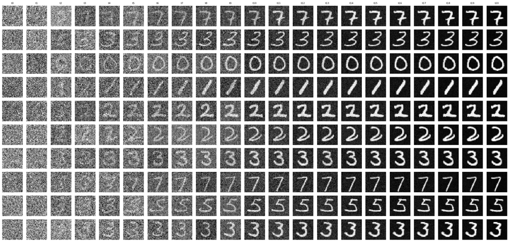

```python
# --- Visualization ---
snapshots = torch.stack(snapshots, dim=1)  # shape: (n_samples, num_snapshots, 1, 28, 28)
rows = n_samples
cols = snapshots.size(1)

fig, axes = plt.subplots(rows, cols, figsize=(cols * 1.1, rows * 1.1))
for r in range(rows):
    for c in range(cols):
        axes[r, c].imshow(snapshots[r, c, 0], cmap='gray')
        axes[r, c].axis('off')
        if r == 0:
            axes[r, c].set_title(f"t{c}", fontsize=8)

plt.tight_layout()
plt.show()
```